# GSEA_Cutsom_Genes

Nikita Telkar

April 12, 2021

## 0.0 Introduction

Here I’ll be running GSEA on a list of custom genes.

## 1.0 Loading Packages and Data

```r
#tidyverse packages
#library(dplyr)
#library(stringr)
#library(readr)
#library(tidyr)
#library(tibble)
#library(forcats)
#library(purrr)
#library(ggplot2)

library(here)
library(readxl)
library(openxlsx)
library(readr)
library(rmarkdown)
library(knitr)
library(stringr)
library(DT)
library(kableExtra)
library(formatR)
library(janitor)
library(scales)
library(ggpubr)
library(gridExtra)
library(RColorBrewer)
library(reshape2)
library(showtext)
library(extrafont)
library(biomaRt)
library(pheatmap)
library(tidyverse)
#GSEA packages
library(fgsea)
library(msigdbr)
```

```r
knitr::opts_chunk$set(fig.showtext = TRUE, fig_retina = 1) #needed to render show_text
knitr::opts_chunk$set(warning = FALSE, error = FALSE, message = FALSE)

#font_add_google("Montserrat", "Mont")

font_paths("C:/Users/nikita.telkar/AppData/Local/Microsoft/Windows/Fonts")
```

```
## [1] "C:\\Users\\nikita.telkar\\AppData\\Local\\Microsoft\\Windows\\Fonts"
## [2] "C:\\Windows\\Fonts"
```

```r
font_add("Montserrat", regular = "Montserrat-Regular.ttf")

showtext_auto()

my_theme <- theme_minimal() +
  theme(plot.title = element_text(family = "Montserrat", size = 14),
        plot.subtitle = element_text(family = "Montserrat", size = 12),
        legend.text = element_text(family = "Montserrat", size = 10),
        axis.title = element_text(family = "Montserrat", size = 14))
```

```r
#ranked logFC with entrez list for all comparison
all_gl <- readRDS(here::here("data", "Processed", "all_ranked_genelists.RDS"))

gl_d10_alid7 <- readRDS(here::here("data", "Processed", "genelists", "gl_d10_alid7.RDS"))
gl_d10_flicRD1 <- readRDS(here::here("data", "Processed", "genelists", "gl_d10_flicRD1.RDS"))
gl_d10_flicRD5 <- readRDS(here::here("data", "Processed", "genelists", "gl_d10_flicRD5.RDS"))
gl_d10_RD1 <- readRDS(here::here("data", "Processed", "genelists", "gl_d10_RD1.RDS"))
gl_d10_RD5 <- readRDS(here::here("data", "Processed", "genelists", "gl_d10_RD5.RDS"))
gl_RD1_flicRD1 <- readRDS(here::here("data", "Processed", "genelists", "gl_RD1_flicRD1.RDS"))
gl_RD5_flicRD5 <- readRDS(here::here("data", "Processed", "genelists", "gl_RD5_flicRD5.RDS"))
gl_RD5_RD1 <- readRDS(here::here("data", "Processed", "genelists", "gl_RD5_RD1.RDS"))
gl_flicRD5_flicRD1 <- readRDS(here::here("data", "Processed", "genelists", "gl_flicRD5_flicRD1.RDS"))

#all DE analysis metrics + parameters from earlier scripts in ibd project
all_metrics <- readRDS(here::here("data", "Processed", "all_gene_metrics.RDS"))

eNorm <- read.xlsx(here::here("data", "Processed", "ibd_eDat_norm.xlsx"), colNames = TRUE, rowNames = TRUE)

pDat <- read.xlsx(here::here("data", "Processed", "ibd_pDat.xlsx"), colNames = TRUE, rowNames = TRUE)

#z-scores
eNorm_scale <- read.xlsx(here::here("data", "Processed", "ibd_eNorm_z-scores.xlsx"), colNames = TRUE, rowNames = TRUE)
```

## 2.0 Stappenbeck Markers

[This Wang Y et al., paper](https://www.sciencedirect.com/science/article/pii/S0092867419311651) is the mouse study that this current project is based on. Referencing their **Figure 2D**, I’m going to pull those markers from our data and check how well the expression aligns with theirs.

### 2.1 Converting mouse genes to their human homologues

Now, the genes which we want to look at are mouse genes. We need to first convert them to their human equivalents.

```r
#stappenbeck markers
stappenbeck_genes <- read_excel(here::here("data", "Processed", "Stappenbeck_Fig2D_markers.xlsx"), col_names = TRUE)
stappenbeck_genes
```

```
## # A tibble: 22 x 2
##    mouse_genes marker
##    <chr>       <chr>
##  1 Atoh1       Secretory_TF
##  2 Gfi1        Secretory_TF
##  3 Spdef       Secretory_TF
##  4 Nkx2-2      Secretory_TF
##  5 Neurog3     Secretory_TF
##  6 Neurod1     Secretory_TF
##  7 Muc2        Goblet
##  8 Tff3        Goblet
##  9 Fcgbp       Goblet
## 10 Agr2        Goblet
## # ... with 12 more rows
```

```r
dim(stappenbeck_genes) #22 genes
```

```
## [1] 22  2
```

```r
mm_genes <- stappenbeck_genes$mouse_genes

# Basic function to convert mouse to human gene names
convertMouseGeneList <- function(x){
require("biomaRt")
human = useMart("ensembl", dataset = "hsapiens_gene_ensembl")
mouse = useMart("ensembl", dataset = "mmusculus_gene_ensembl")

genesV2 = getLDS(attributes = c("mgi_symbol"), filters = "mgi_symbol", values = x , mart = mouse, attributesL = c("hgnc_symbol"), martL = human, uniqueRows=T)
humanx <- unique(genesV2[, 2])

return(humanx)
}

mm_genes <- convertMouseGeneList(mm_genes)
mm_genes <- as.data.frame(mm_genes)
dim (mm_genes)
```

```
## [1] 18  1
```

Hmm, not all genes are returned (18 /22). Let’s try converting all mouse genes to upper case and joining to see which genes aren’t matching.

```r
stappenbeck_genes <- stappenbeck_genes %>%
  mutate(upper = toupper(mouse_genes))

which(stappenbeck_genes$upper %in% mm_genes$mm_genes)
```

```
##  [1]  1  2  3  4  5  6 10 11 12 13 14 16 18 19 20 21 22
```

```r
not_in_human <- stappenbeck_genes %>%
  anti_join(mm_genes, by = c("upper" = "mm_genes"))

not_in_human
```

```
## # A tibble: 5 x 3
##   mouse_genes marker           upper
##   <chr>       <chr>            <chr>
## 1 Muc2        Goblet           MUC2
## 2 Tff3        Goblet           TFF3
## 3 Fcgbp       Goblet           FCGBP
## 4 Fcgbp       Entero-endocrine FCGBP
## 5 Car4        Colonocyte       CAR4
```

By manually checking, all 5 genes not matching between biomaRt for *whatever reason* are present in Genecards. It’s only Car4 which is present as CA4 in humans.

I’m also going to find a mouse-to-human homologue file to get the human gene ids of the respective mouse one, just in case. The HOM_MouseHumanSequence.rpt file is the one - let’s take a look at that text file.

```r
mouse_to_human <- read.delim(here::here("data", "Processed", "HOM_MouseHumanSequence.rpt.txt"), sep = "\t", header = TRUE)

head(mouse_to_human)
```

```
##   HomoloGene.ID Common.Organism.Name NCBI.Taxon.ID Symbol EntrezGene.ID
## 1             3    mouse, laboratory         10090  Acadm         11364
## 2             3                human          9606  ACADM            34
## 3             5    mouse, laboratory         10090 Acadvl         11370
## 4             5                human          9606 ACADVL            37
## 5             6    mouse, laboratory         10090  Acat1        110446
## 6             6                human          9606  ACAT1            38
##   Mouse.MGI.ID HGNC.ID OMIM.Gene.ID Genetic.Location
## 1    MGI:87867                         Chr3 78.77 cM
## 2              HGNC:89  OMIM:607008       Chr1 p31.1
## 3   MGI:895149                        Chr11 42.96 cM
## 4              HGNC:92  OMIM:609575      Chr17 p13.1
## 5    MGI:87870                         Chr9 29.12 cM
## 6              HGNC:93  OMIM:607809      Chr11 q22.3
##   Genomic.Coordinates..mouse....human...
```

[output cut: 27 more lines]

I’ll separate the mouse and human rows, and then match them by homologue so that we have all the data is a workable format. I’ll then join that dataframe to the `stappenbeck file`, and add the entrez IDs.

```r
# mouse <- mouse_to_human %>%
#   filter(Common.Organism.Name == "mouse, laboratory") %>%
#   dplyr::select(HomoloGene.ID, Symbol)
#
# human <- mouse_to_human %>%
#   filter(Common.Organism.Name == "human") %>%
#   dplyr::select(HomoloGene.ID, Symbol)
#
# mm_to_HGNC <- mouse %>%
#   full_join(human, by = "HomoloGene.ID")
#
# colnames(mm_to_HGNC) <- c("Homologue_number", "mouse", "human")
#write.xlsx(mm_to_HGNC, file = here::here("data", "Processed", "mouse_human_homologues.xlsx"), colnames = TRUE)

mm_to_HGNC <- read.xlsx(here::here("data", "Processed", "mouse_human_homologues.xlsx"), colNames = TRUE, rowNames = FALSE)

stappenbeck_genes <- stappenbeck_genes %>%
  left_join(mm_to_HGNC, by = c("mouse_genes" = "mouse"))

custom_genes <- stappenbeck_genes %>%
  dplyr::select(human)

custom_genes
```

```
## # A tibble: 22 x 1
##    human
##    <chr>
##  1 ATOH1
##  2 GFI1
##  3 SPDEF
##  4 NKX2-2
##  5 NEUROG3
##  6 NEUROD1
##  7 MUC2
##  8 TFF3
##  9 FCGBP
## 10 AGR2
## # ... with 12 more rows
```

```r
#making a dataframe of ALL Entrez to HGNC via MSigDb
# HGNC_to_Entrez <- msigdbr(species = "Homo sapiens")
#
# HGNC_to_Entrez <- HGNC_to_Entrez %>%
#   dplyr::select(human_gene_symbol, human_entrez_gene) %>%
#   distinct(human_gene_symbol, .keep_all = TRUE)
#write.xlsx(HGNC_to_Entrez, file = here::here("data", "Processed", "HGNC_to_Entrez.xlsx"), colnames = TRUE)

HGNC_to_Entrez <- read.xlsx(here::here("data", "Processed", "HGNC_to_Entrez.xlsx"), colNames = TRUE, rowNames = FALSE)

custom_genes <- custom_genes %>%
  inner_join(HGNC_to_Entrez, by = c("human" = "human_gene_symbol")) %>%
  dplyr::select(human_entrez_gene)
```

We now have the mouse to human equivalent genes.

### 2.2 GSEA

Let’s now make our custom genes list/set into a `fgsea` useable object and compute the GSEA.

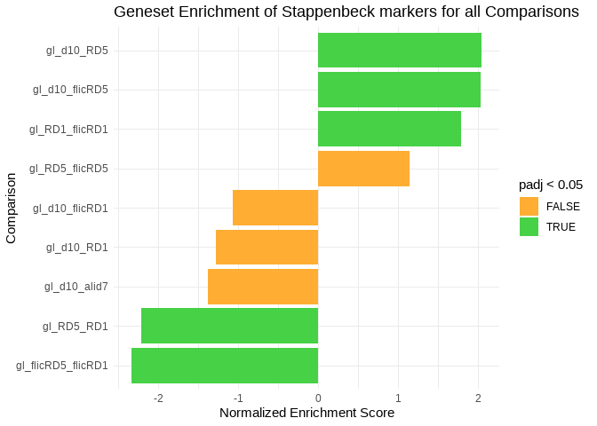

```r
custom_genes$term <- "STAPPENBECK_MARKERS"

colnames (custom_genes) [1] <- "gene"

custom_genes <- custom_genes[c(2,1)]



custom_genes <- split(x = custom_genes$gene, f = custom_genes$term)

fgsea_custom <- list()

for (i in 1:length(all_gl)){
fgsea_custom[[i]] <- fgsea(custom_genes, all_gl[[i]])
}

#using map instead of for loop
test <- list()
test <- map(all_gl, function(x) fgsea(custom_genes, x) )

names(fgsea_custom) <- names(all_gl)
dfnames <- names(all_gl)

fgsea_custom <- do.call(rbind, fgsea_custom)
fgsea_custom <- as.data.frame(fgsea_custom)
#write.xlsx(fgsea_custom, file = here::here("data", "Processed", "ibd_fgsea_stappenbeck_FIG2D_results.xlsx"), colnames = TRUE)

row.names(fgsea_custom) <- dfnames

fgsea_custom <- fgsea_custom %>%
  rownames_to_column(var = "comparison")

fgsea_custom %>%
  ggplot(aes(x = reorder(comparison, NES), y = NES)) +
  geom_col(aes(fill = padj < 0.05)) +
  scale_fill_manual(values = c("#ffad33", "#47d147")) +
  coord_flip() +
  labs(x = "Comparison", y = "Normalized Enrichment Score", title = "Geneset Enrichment of Stappenbeck markers for all Comparisons") +
  theme_minimal()
```

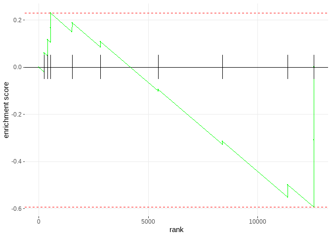

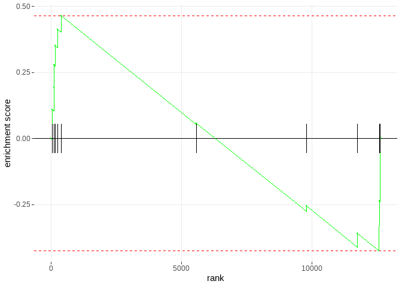

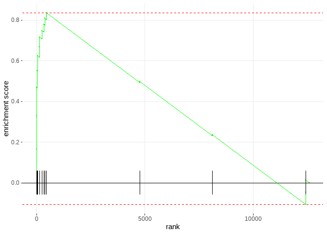

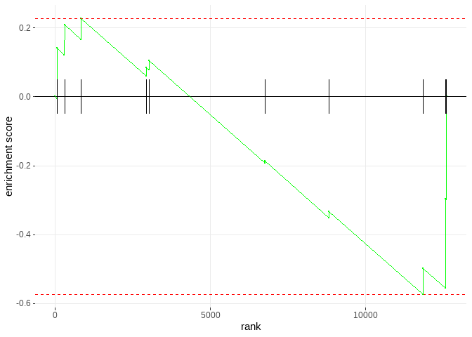

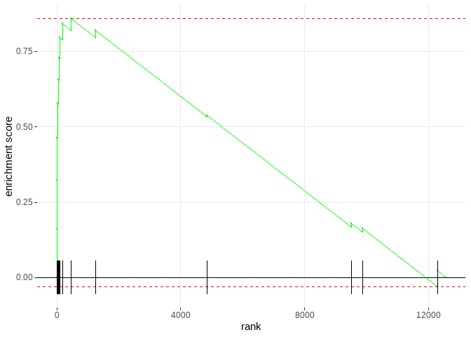

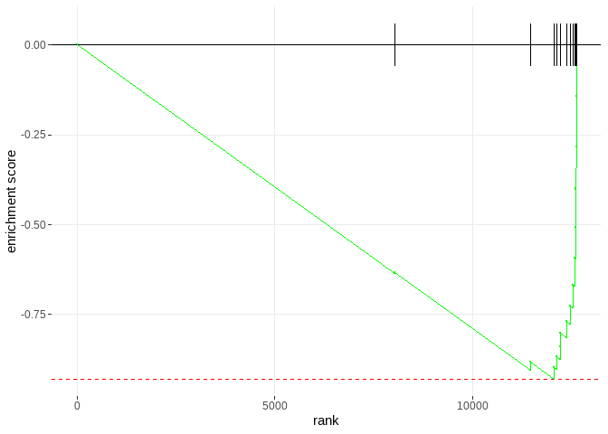

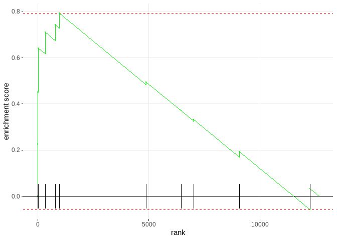

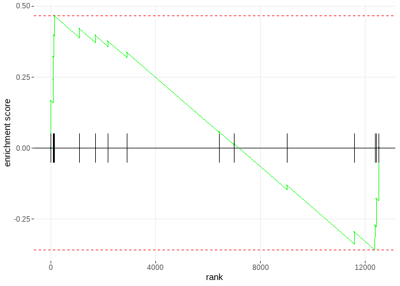

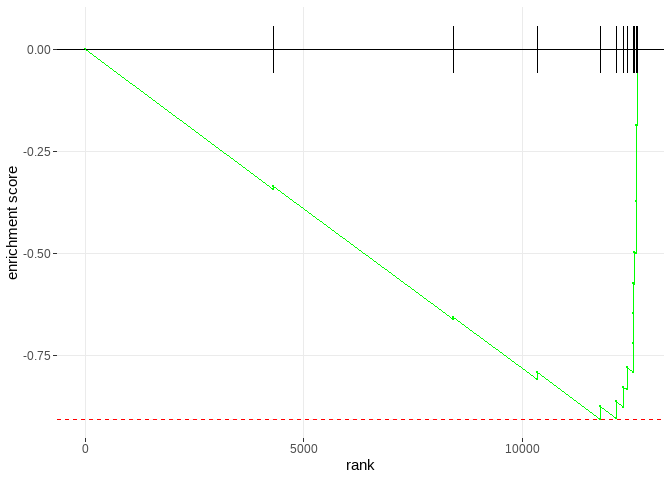

```r
custom_enrichplots <- list

custom_enrichplots <- list(
plotEnrichment(custom_genes[[1]], gl_d10_alid7),
plotEnrichment(custom_genes[[1]], gl_d10_flicRD1),
plotEnrichment(custom_genes[[1]], gl_d10_flicRD5),
plotEnrichment(custom_genes[[1]], gl_d10_RD1),
plotEnrichment(custom_genes[[1]], gl_d10_RD5),
plotEnrichment(custom_genes[[1]], gl_flicRD5_flicRD1),
plotEnrichment(custom_genes[[1]], gl_RD1_flicRD1),
plotEnrichment(custom_genes[[1]], gl_RD5_flicRD5),
plotEnrichment(custom_genes[[1]], gl_RD5_RD1)
)


# for (i in 1:length(all_gl)) {
# custom_enrichplots[[i]] <- plotEnrichment(custom_genes$STAPPENBECK_MARKERS, all_gl[[i]])
# }

names(custom_enrichplots) <- names(all_gl)
custom_enrichplots
```